# Data Visualization with ggplot2 (part 1)

*counting things, variable distributions, ridgelines, and violin plots*

# Outline

1. Import Apple Mobility Data
2. Wrangle Apple Mobility Data
3. Counting things
4. Histograms
5. Density plots
6. Ridgeline plots
7. Violin plots

# Objectives

In order to use graphs and figures to effectively communicate with our audience, we need to consider a few things:

1. Recognize the needs of your audience (who are they, and where are they coming from?)
- *level of data literacy, subject matter expertise, etc.*
2. Communicate the quality of the data with stakeholders (can we answer their question(s) with the available data?)
- *let them know the good and the bad news*
3. Identify the correct data visualization (based on the data *and* the problem/question)
- *single variable, bivariate, and multivariate graphs*

# Materials

View the slides for this section [here](https://mjfrigaard.github.io/FA22-JOUR301/slides/ggp2-part-01.html#1).

# More resources

Read more about [`ggplot2`](https://ggplot2.tidyverse.org/index.html) on the tidyverse website, and in the [Data Visualisation](https://r4ds.had.co.nz/data-visualisation.html) chapter of R for Data Science.

# Load the packages

The main packages we’re going to use are `dplyr`, `tidyr`, and `ggplot2`. These are all part of the `tidyverse`, so we’ll import this package below:

```r
install.packages("tidyverse")
library(tidyverse)
```

# Example: COVID and Mobility

Assume we received the following questions:

*How has COVID changed our modes of transportation?*

Or

*Are people using fewer or different forms of transportation since the COVID pandemic?*

Questions we should be considering:

1. What kind of measurements would this be?
- *how people travel (walk, drive, etc.)*
2. What would these data look like?
- *what would the columns and rows look like?*

## Data Import

We did some digging and came up with the following dataset to try and answer the questions above:

- Apple mobility data: https://covid19.apple.com/mobility

### Import

Import the data below

```r
AppleMobRaw <- readr::read_csv("https://bit.ly/3DEDa8T")
```

View the `head()` and `tail()`

```r
head(AppleMobRaw)
```

```
#> # A tibble: 6 × 322
#>   geo_type      region trans…¹ sub-r…² country 2020-…³ 2020-…⁴ 2020-…⁵
#>   <chr>         <chr>  <chr>   <chr>   <chr>     <dbl>   <dbl>   <dbl>
#> 1 country/regi… Alban… driving <NA>    <NA>        100    95.3   101.
#> 2 country/regi… Alban… walking <NA>    <NA>        100   101.     98.9
#> 3 country/regi… Argen… driving <NA>    <NA>        100    97.1   102.
#> 4 country/regi… Argen… walking <NA>    <NA>        100    95.1   101.
#> 5 country/regi… Austr… driving <NA>    <NA>        100   103.    104.
#> 6 country/regi… Austr… transit <NA>    <NA>        100   102.    101.
#> # … with 314 more variables: `2020-01-16` <dbl>, `2020-01-17` <dbl>,
#> #   `2020-01-18` <dbl>, `2020-01-19` <dbl>, `2020-01-20` <dbl>,
#> #   `2020-01-21` <dbl>, `2020-01-22` <dbl>, `2020-01-23` <dbl>,
#> #   `2020-01-24` <dbl>, `2020-01-25` <dbl>, `2020-01-26` <dbl>,
#> #   `2020-01-27` <dbl>, `2020-01-28` <dbl>, `2020-01-29` <dbl>,
#> #   `2020-01-30` <dbl>, `2020-01-31` <dbl>, `2020-02-01` <dbl>,
#> #   `2020-02-02` <dbl>, `2020-02-03` <dbl>, `2020-02-04` <dbl>, …
```

```r
tail(AppleMobRaw)
```

```
#> # A tibble: 6 × 322
#>   geo_type region      trans…¹ sub-r…² country 2020-…³ 2020-…⁴ 2020-…⁵
#>   <chr>    <chr>       <chr>   <chr>   <chr>     <dbl>   <dbl>   <dbl>
#> 1 county   York County walking South … United…     100   102.    115.
#> 2 county   York County walking Pennsy… United…     100   110.    122.
#> 3 county   Young Coun… driving Texas   United…     100    98.8    97.8
#> 4 county   Yuba County driving Califo… United…     100   103.    103.
#> 5 county   Yuma County driving Arizona United…     100   102.    107.
#> 6 county   Yuma County walking Arizona United…     100    95.9    99.0
#> # … with 314 more variables: `2020-01-16` <dbl>, `2020-01-17` <dbl>,
#> #   `2020-01-18` <dbl>, `2020-01-19` <dbl>, `2020-01-20` <dbl>,
#> #   `2020-01-21` <dbl>, `2020-01-22` <dbl>, `2020-01-23` <dbl>,
#> #   `2020-01-24` <dbl>, `2020-01-25` <dbl>, `2020-01-26` <dbl>,
#> #   `2020-01-27` <dbl>, `2020-01-28` <dbl>, `2020-01-29` <dbl>,
#> #   `2020-01-30` <dbl>, `2020-01-31` <dbl>, `2020-02-01` <dbl>,
#> #   `2020-02-02` <dbl>, `2020-02-03` <dbl>, `2020-02-04` <dbl>, …
```

### Tidy

We can see the dates are structured across the columns, so we need to restructure these into a tidy format. Read more about this format [here](https://r4ds.had.co.nz/tidy-data.html).

```r
AppleMobRaw %>%
  tidyr::pivot_longer(cols = -c(geo_type:country),
                      names_to = "date",
                      values_to = "dir_request")
```

```
#> # A tibble: 1,487,047 × 7
#>    geo_type       region  transportati…¹ sub-r…² country date  dir_r…³
#>    <chr>          <chr>   <chr>          <chr>   <chr>   <chr>   <dbl>
#>  1 country/region Albania driving        <NA>    <NA>    2020…   100
#>  2 country/region Albania driving        <NA>    <NA>    2020…    95.3
#>  3 country/region Albania driving        <NA>    <NA>    2020…   101.
#>  4 country/region Albania driving        <NA>    <NA>    2020…    97.2
#>  5 country/region Albania driving        <NA>    <NA>    2020…   104.
#>  6 country/region Albania driving        <NA>    <NA>    2020…   113.
#>  7 country/region Albania driving        <NA>    <NA>    2020…   105.
#>  8 country/region Albania driving        <NA>    <NA>    2020…    94.4
#>  9 country/region Albania driving        <NA>    <NA>    2020…    94.1
#> 10 country/region Albania driving        <NA>    <NA>    2020…    93.5
#> # … with 1,487,037 more rows, and abbreviated variable names
#> #   ¹transportation_type, ²`sub-region`, ³dir_request
```

### Missing

Now that we have the data in a tidy format, we should remove the missing values from `country` and `sub-region`

```r
AppleMobRaw %>%
  tidyr::pivot_longer(cols = -c(geo_type:country),
                      names_to = "date", values_to = "dir_request") %>%
    # remove missing country and missing sub-region data
  dplyr::filter(!is.na(country) & !is.na(`sub-region`))
```

```
#> # A tibble: 1,055,293 × 7
#>    geo_type region transportation_type sub-reg…¹ country date  dir_r…²
#>    <chr>    <chr>  <chr>               <chr>     <chr>   <chr>   <dbl>
#>  1 city     Aachen driving             North Rh… Germany 2020…   100
#>  2 city     Aachen driving             North Rh… Germany 2020…   101.
#>  3 city     Aachen driving             North Rh… Germany 2020…   103.
#>  4 city     Aachen driving             North Rh… Germany 2020…   103.
#>  5 city     Aachen driving             North Rh… Germany 2020…   109.
#>  6 city     Aachen driving             North Rh… Germany 2020…   110.
#>  7 city     Aachen driving             North Rh… Germany 2020…    98.2
#>  8 city     Aachen driving             North Rh… Germany 2020…   103.
#>  9 city     Aachen driving             North Rh… Germany 2020…   104.
#> 10 city     Aachen driving             North Rh… Germany 2020…   102.
#> # … with 1,055,283 more rows, and abbreviated variable names
#> #   ¹`sub-region`, ²dir_request
```

### Mutate

Use `mutate()` to create a properly formatted `date` variable, and `rename()` the `transportation_type` variable to `trans_type`. Apply `janitor::clean_names()` to the entire dataset and assign the final output to `TidyApple`.

```r
AppleMobRaw %>%
  tidyr::pivot_longer(cols = -c(geo_type:country),
                      names_to = "date", values_to = "dir_request") %>%
    # remove missing country and missing sub-region data
  dplyr::filter(!is.na(country) & !is.na(`sub-region`)) %>%
  # format date
  mutate(date = lubridate::ymd(date)) %>%
  # change name of transportation types
  rename(trans_type = transportation_type) %>%
  # clean names
  janitor::clean_names() -> TidyApple
```

## Counting

One of the most important jobs of analytic work is [counting things](https://cran.r-project.org/web/packages/janitor/vignettes/tabyls.html). There are many ways to accomplish this in R, but we’ll stick with the `dplyr` package because it’s part of the `tidyverse`.

The `dplyr` function for counting responses of a categorical or factor variable is `count()`, and it works like this:

```r
Data %>%
  count(variable)
```

### Count

So, if we wanted to count the number of different transportation types in the `TidyApple` data frame, it would look like this,

```r
TidyApple %>%
  dplyr::count(trans_type)
```

```
#> # A tibble: 3 × 2
#>   trans_type      n
#>   <chr>       <int>
#> 1 driving    743682
#> 2 transit    106512
#> 3 walking    205099
```

### Sort

We can also sort the responses using the `sort = TRUE` argument.

```r
TidyApple %>%
  dplyr::count(trans_type, sort = TRUE)
```

```
#> # A tibble: 3 × 2
#>   trans_type      n
#>   <chr>       <int>
#> 1 driving    743682
#> 2 walking    205099
#> 3 transit    106512
```

### Iterate

We can also combine `dplyr::select_if()` and `purrr::map()` to pass the `count()` function to all the character variables in `TidyApple`.

```r
TidyApple %>%
  select_if(is.character) %>%
  map(~count(data.frame(x = .x), x, sort = TRUE)) -> tidy_apple_counts
```

We can example the counts of each value by using the `$` to subset the `tidy_apple_counts` list.

```r
head(tidy_apple_counts$sub_region)
```

```
#>            x     n
#> 1      Texas 76397
#> 2 California 52622
#> 3    Georgia 41527
#> 4   Virginia 38991
#> 5    Florida 38357
#> 6       Ohio 38357
```

```r
head(tidy_apple_counts$region)
```

```
#>                   x    n
#> 1 Washington County 8559
#> 2  Jefferson County 7925
#> 3 Montgomery County 7608
#> 4   Franklin County 6974
#> 5    Madison County 6657
#> 6    Jackson County 6023
```

# Visualizing Distributions

Before we start looking at relationships *between* variables, we should examine each variable’s underlying distribution. In the next section, we’re going to cover a few graphs that display variable distributions: histograms, density, violin, and ridgeline plots,

## Histograms

A histogram is a special kind of bar graph–it only takes a single continuous variable (in this case, `dir_request`), and it displays a relative breakdown of the values.

The `x` axis for the histogram will have the direction requests, and the `y` variable will display a count of the values.

```r
lab_hist <- labs(x = "Apple directions requests",
                 y = "Count",
     title = "Distribution of Direction Requests",
     subtitle = "source: https://covid19.apple.com/mobility")
```

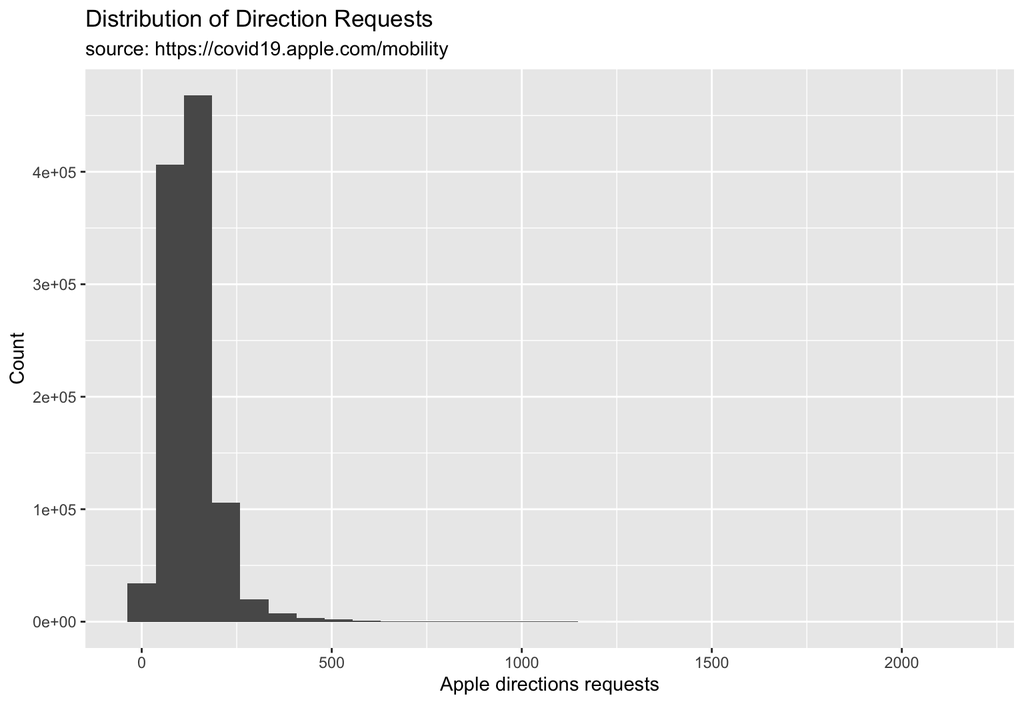

```r
TidyApple %>% ggplot() +
  geom_histogram(aes(x = dir_request)) +
  lab_hist
```

## Adjusting Y Axes

We can see the `y` axis of the histogram is in scientific notation. This might be hard for some audiences to interpret, so we will change this to use the whole number with commas with the [`scales` package](https://scales.r-lib.org/).

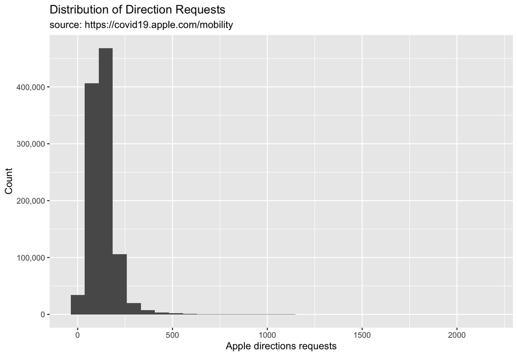

```r
library(scales)
TidyApple %>% ggplot() +
  geom_histogram(aes(x = dir_request)) +
  scale_y_continuous(labels = scales::comma) +
  lab_hist
```

## Histogram Shape

We can control the shape of the histogram with the `bins` argument. The default is `30`.

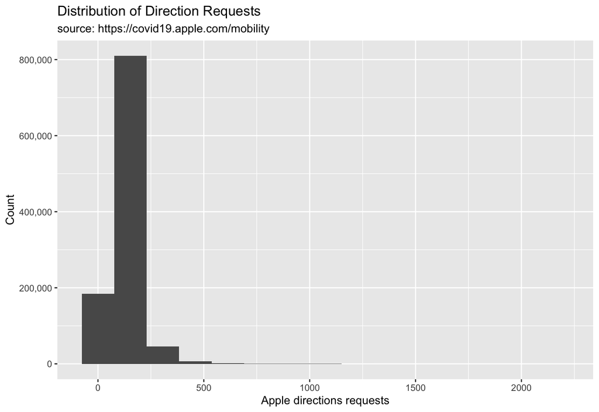

```r
TidyApple %>% ggplot() +
  geom_histogram(aes(x = dir_request), bins = 15) +
  scale_y_continuous(labels = scales::comma) +
  lab_hist
```

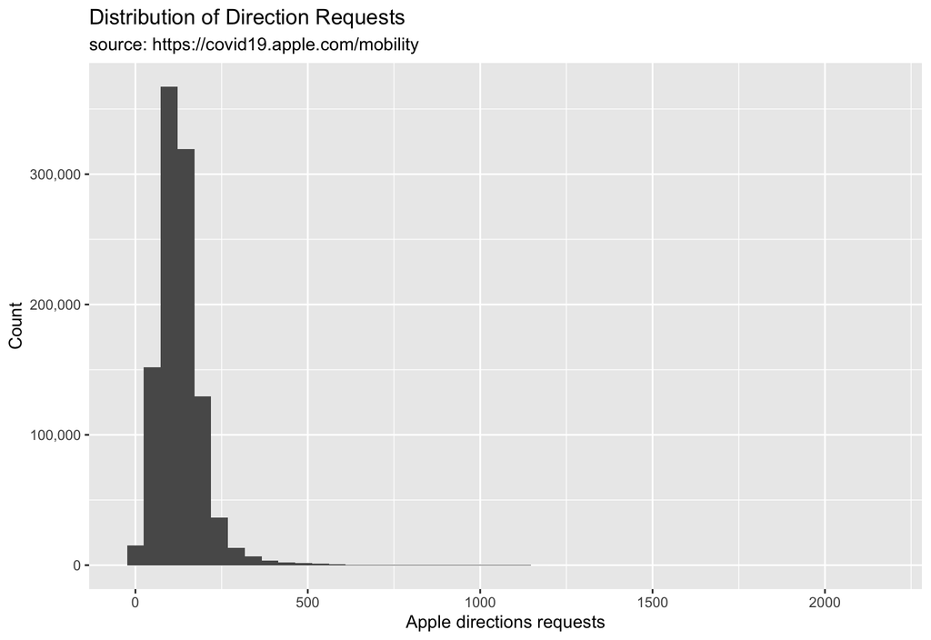

```r
TidyApple %>% ggplot() +
  geom_histogram(aes(x = dir_request), bins = 45) +
  scale_y_continuous(labels = scales::comma) +
  lab_hist -> gg_hist45
```

## Density Plots

What if we want to see how a continuous variable is distributed across a categorical variable? We covered this in the [previous lesson with a boxplot](https://mjfrigaard.github.io/data-viz-intro/Index.html#87).

Density plots come in handy here (so do `geom_boxplot()`s!). Read more about the density geom [here](https://ggplot2.tidyverse.org/reference/geom_density.html).

We are going to create the graph labels so we know what to expect when we build our graph, and we want to see the distribution of the directions request, filled by the levels of transportation type.

```r
lab_density <- labs(x = "Apple directions requests",
                    fill = "Transit Type",
     title = "Distribution of Direction Requests vs. Transportation Type",
     subtitle = "source: https://covid19.apple.com/mobility")
```

Now we build the density plot, passing the variables so they match our labels above.

*One drawback to density plots is the `y` axis can be hard to interpret*

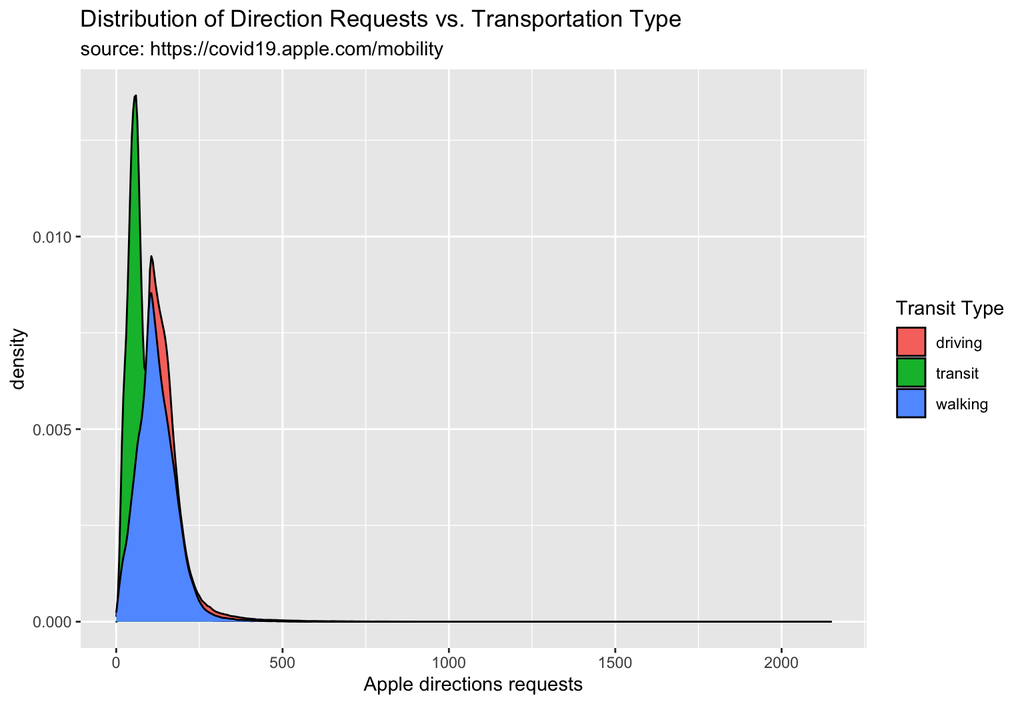

```r
TidyApple %>%
  ggplot() +
  geom_density(aes(x = dir_request, fill = trans_type)) +
  lab_density
```

Adjust the overlapping densities by setting `alpha` to `1/3`.

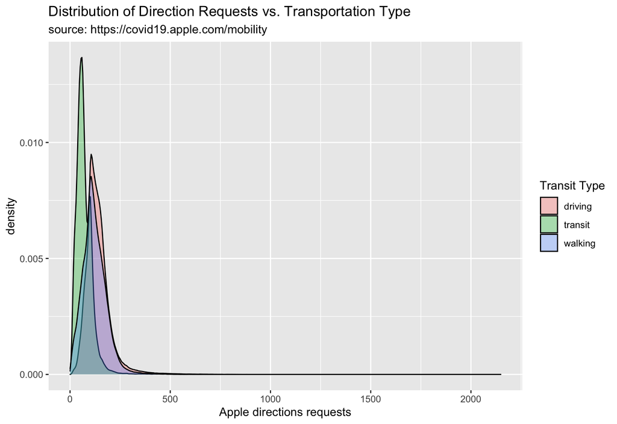

```r
TidyApple %>%
  ggplot() +
  geom_density(aes(x = dir_request, fill = trans_type),
               alpha = 1/3) +
  lab_density -> gg_density

gg_density
```

## Ridgeline Plots

Another option is a ridgeline plot (from the `ggridges` package). These display multiple densities.

```r
lab_ridges <- labs(
     title = "Direction Requests by Transportation Type",
     subtitle = "source: https://covid19.apple.com/mobility",
     fill = "Transit type",
     x = "Apple directions requests",
     y = "Transportation Types")
```

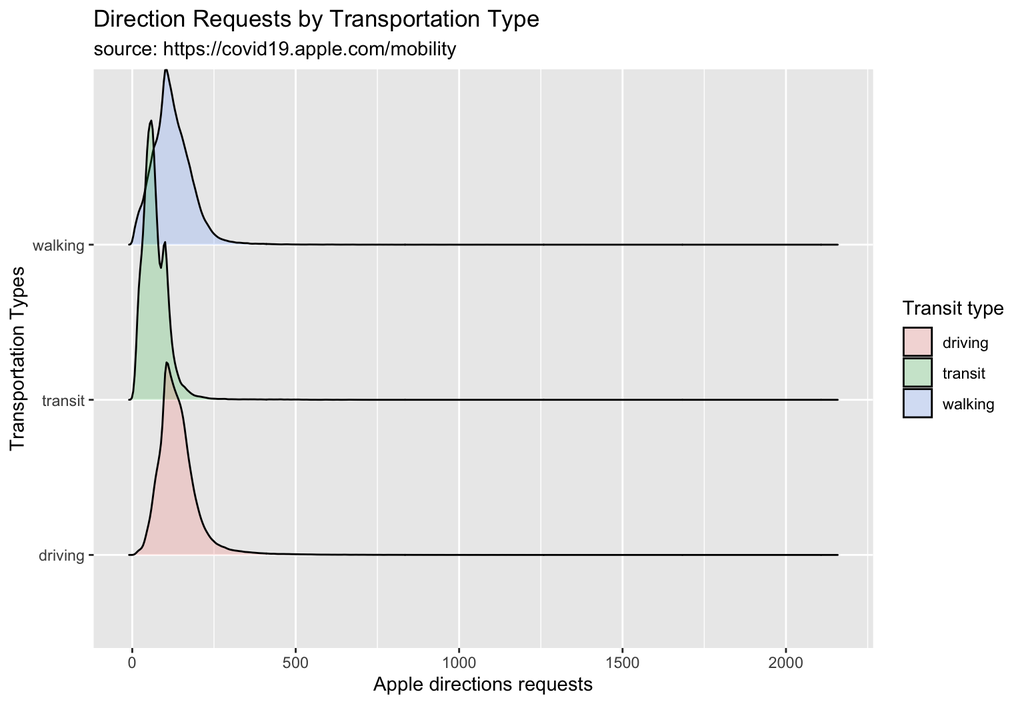

```r
library(ggridges)
TidyApple %>%
  ggplot() +
  geom_density_ridges(aes(x = dir_request,
                          y = trans_type,
                          fill = trans_type),
                      alpha = 1/5) +
  lab_ridges
```

## Violin Plots

Another alternative to the density plot is the violin plot.

```r
lab_violin <- labs(x = "Transit Type",
                   y = "Apple directions requests",
                   fill = "Transit Type",
     title = "Distribution of Direction Requests vs. Transportation Type",
     subtitle = "source: https://covid19.apple.com/mobility")
```

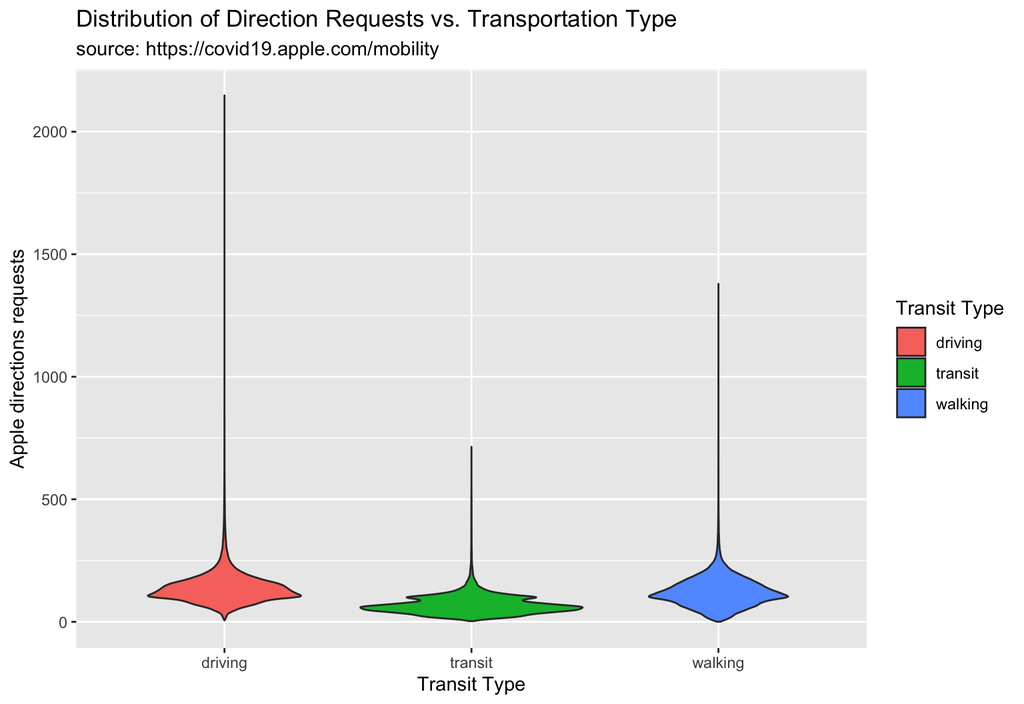

```r
TidyApple %>%
  ggplot() +
  geom_violin(aes(y = dir_request, x = trans_type,
                  fill = trans_type)) +
  lab_violin
```

We can see how `geom_violin`s and `geom_boxplot`s are related by adding a `geom_boxplot()` layer to the graph above. Note we set the `alpha` to `1/5` for the `geom_violin()`, and the `color` to `trans_type` for the `geom_boxplot()`.

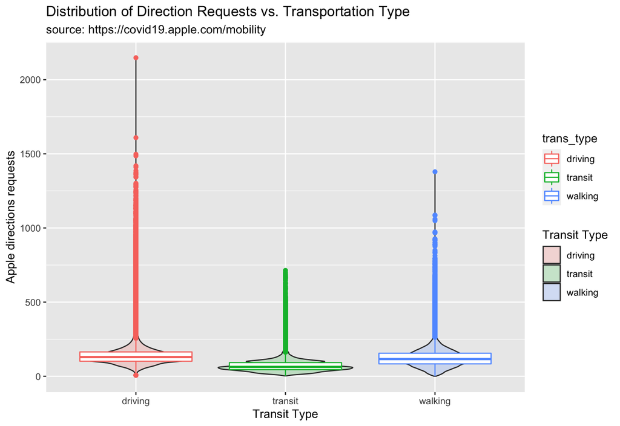

```r
TidyApple %>%
  ggplot() +
  geom_violin(aes(y = dir_request, x = trans_type,
                  fill = trans_type), alpha = 1/5) +
  geom_boxplot(aes(y = dir_request, x = trans_type,
                   color = trans_type)) +
  lab_violin
```

## Export the data

You’ll want to export the `TidyApple` dataset for the next set of exercise.

The code chunk below exports the dataset as a .csv.

```r
readr::write_csv(x = TidyApple,
  file = "data/TidyApple.csv")
```